# Fall 2021 - Math 421 - Midterm

## II. Data Visualization

```r
#df1, "yod", "payfix","pay_ub92","age",
#                      "sex","raceethn","provider","moa",
#                      "yoa","mod","admtype", "asource" ,
#                      "preopday" ,"los", "service" , "icu","ccu",
#                      "dispub92", "payer"  ,"drg","trandb",
#                      "randbg","randbs","orr", "anes","seq",
#                      "lab","dtest", "ther","blood","phar",
#                      "other","patcon","bwght","total","tot" ,
#                      "ecodub92","b_wt","pt_state","diag_adm","ancilar" ,
#                      "campus","er_fee","er_chrg","er_mode","obs_chrg",
#                      "obs_hour","psycchrg","nicu_day"
```

Continue with the data from part I.

1. Provides at least 10 meaningful plots. Comments on the plots. All plots should have title, caption, appropriate labels on x and y-axis Plot 1:

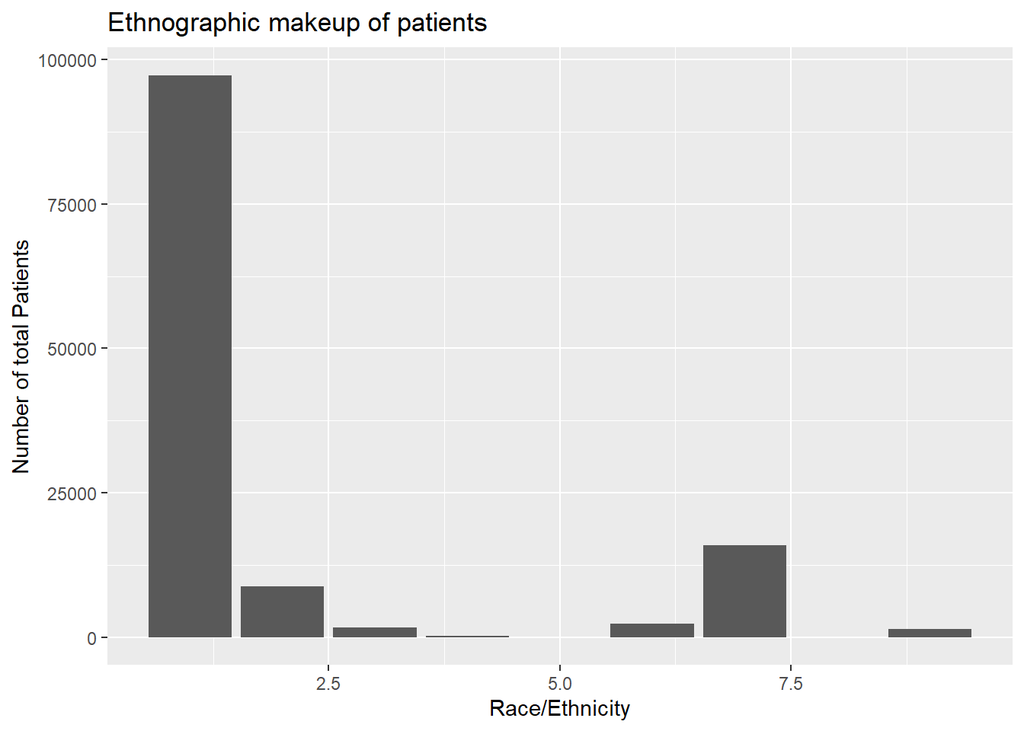

```r
# Overall ethnographic makeup of admitted patients

df2 %>%
  ggplot()+
  labs(title = "Ethnographic makeup of patients", x = "Race/Ethnicity", y = "Number of total Patients")+
  geom_bar(mapping= aes(x= raceethn))
```

```r
# As shown with the graph below the data is heavily weighted with
# white ethnicity which is something important to keep in mind
```

plot 2:

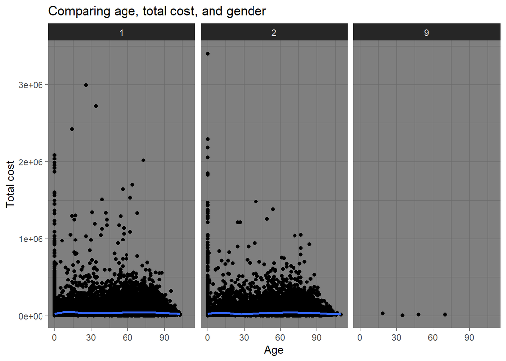

```r
  df2 %>%
  ggplot(mapping= aes(x=age, y = tot))+
  labs(title = "Comparing age, total cost, and gender", x = "Age", y = "Total cost")+
  geom_point()+
  geom_smooth()+
  facet_wrap(~sex)+
  theme_dark()
```

Plot 3

[figure not shown]

```r
#
df2 %>% filter(age > 21) %>% ggplot()+
  labs(title = "Cost to patients over 21", x = "Age", y = "Number of Patients")+
  geom_point(mapping = aes(x = age, y = tot, color = raceethn))
```

Plot 4

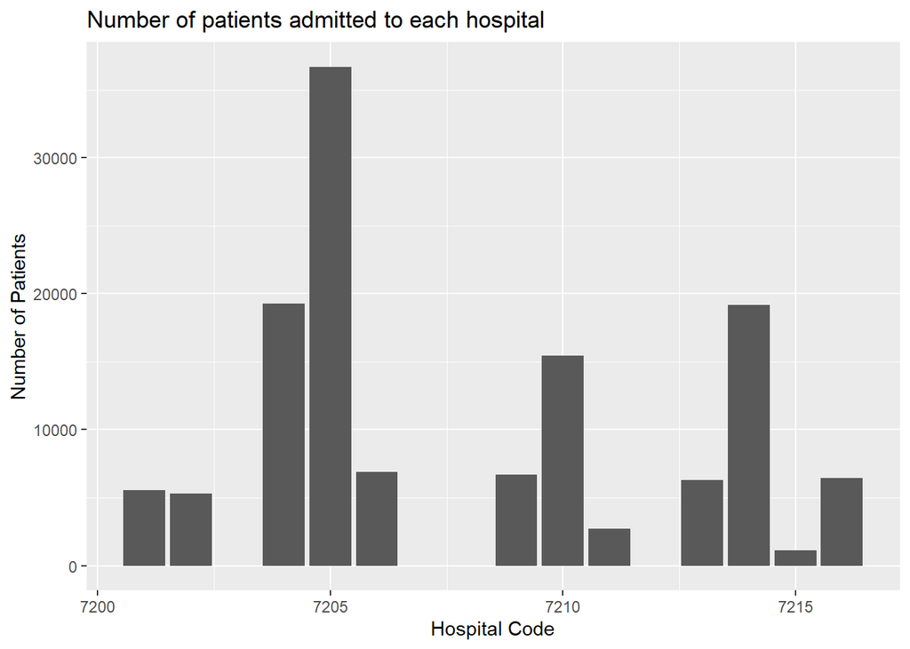

```r
# Line plot

df2 %>% ggplot()+
  labs(title = "Number of patients admitted to each hospital", x = "Hospital Code", y = "Number of Patients")+
  geom_bar(mapping = aes(x = df2$provider))
```

Plot 5

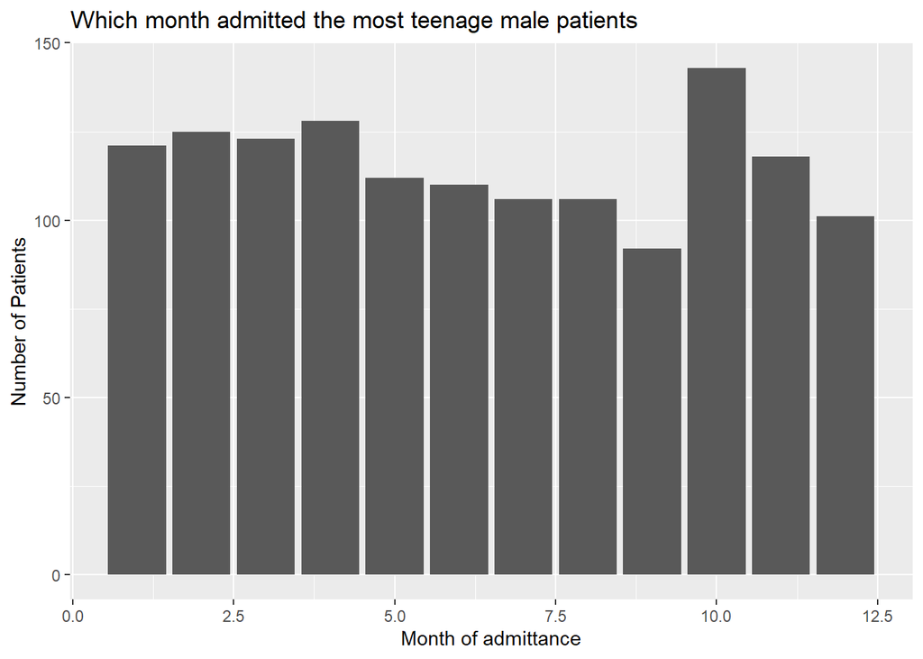

```r
# Is there a difference between gender when comparing the total amount paid
#df3 <- df2 %>% filter (sex == 1)
#table(df3$moa)
# Which month admitted the most male patients?
df10 %>%
  ggplot()+
  labs(title = "Which month admitted the most teenage male patients", x = "Month of admittance", y = "Number of Patients")+
  geom_bar(mapping= aes(x=df10$moa))
```

```r
# October is the month that admitted the most teenage male patients
```

Plot 6

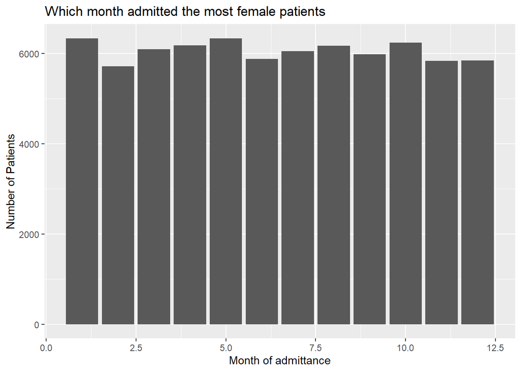

```r
# Which month admitted the most female patients?
df4 %>%
  ggplot()+
  labs(title = "Which month admitted the most female patients", x = "Month of admittance", y = "Number of Patients")+
  geom_bar(mapping= aes(x=df4$moa))
```

```r
# As shown from the graph below january admitted the most female patients
```

Plot 7

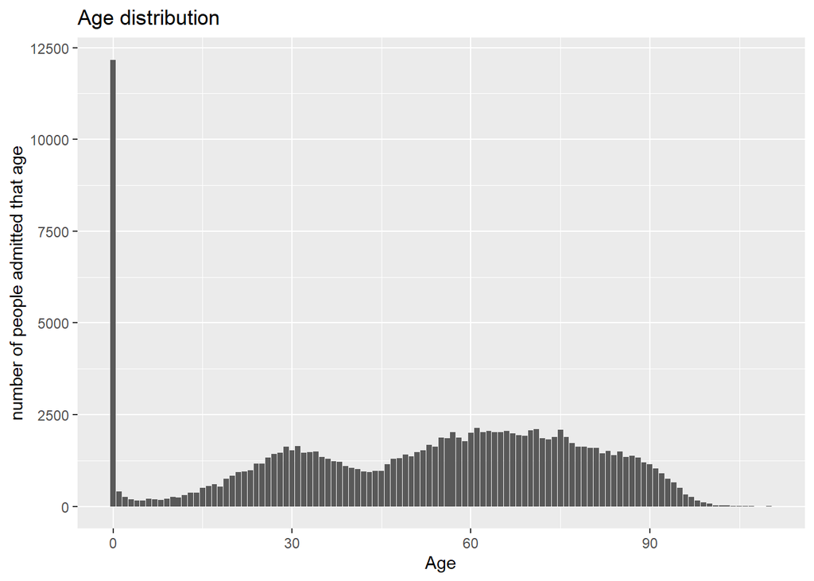

```r
# How many people admitted based on age
df2 %>%
  ggplot()+
  labs(title = "Age distribution", x = "Age", y = "number of people admitted that age")+
  geom_bar(mapping= aes(x=age))
```

Plot 8

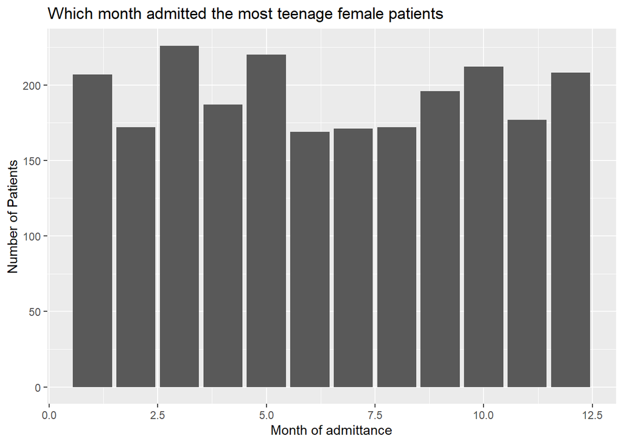

```r
# The data shows that march admitted the most number of teenage female patients

df5 %>%
  ggplot()+
  labs(title = "Which month admitted the most teenage female patients", x = "Month of admittance", y = "Number of Patients")+
  geom_bar(mapping= aes(x=df5$moa))
```

```r
# The data shows that march admitted the most number of teenage female patients
```

Plot 9

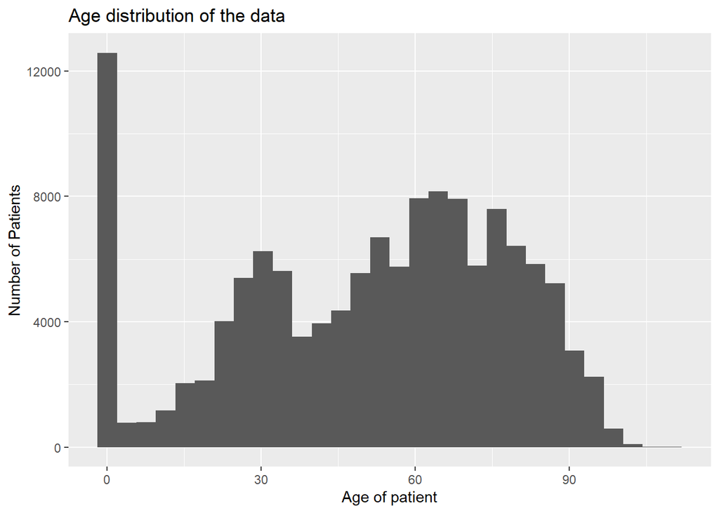

```r
df2 %>%
  ggplot()+
  labs(title = "Age distribution of the data", x = "Age of patient", y = "Number of Patients")+
  geom_histogram(mapping= aes(x=df2$age))
```

Plot 10

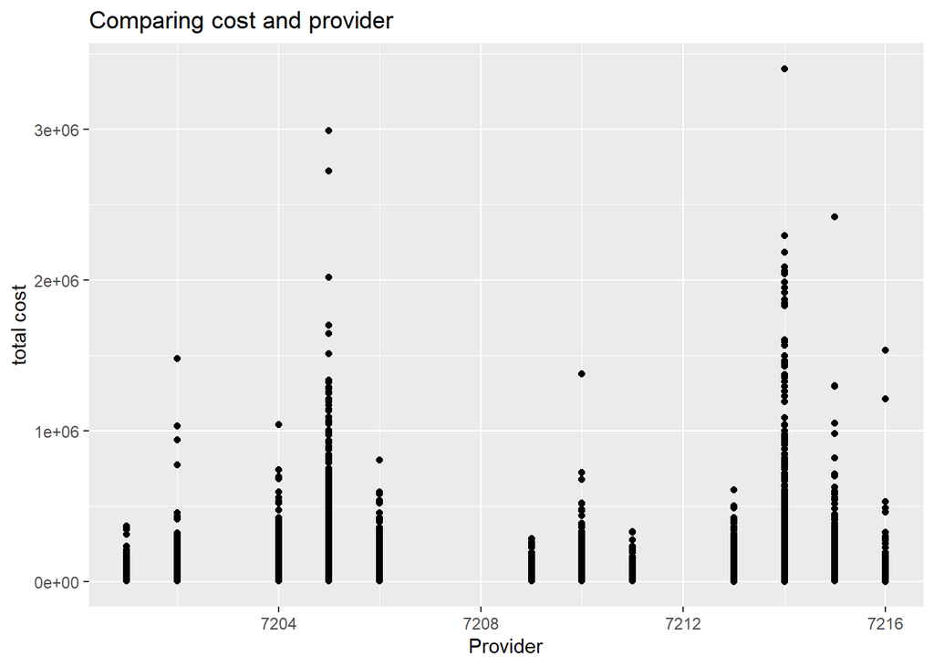

```r
df2 %>%
  ggplot()+
  labs(title = "Comparing cost and provider", x = "Provider", y = "total cost")+
  geom_point(mapping= aes (x=provider, y = tot))
```

```r
# Provider  7201 = Newport
            #7202 = St. Joseph Health Services of RI
            #7203 = Memorial
            #7204 = Miriam
            #7205 = Rhode Island Hospital
            #7206 = Roger Williams
            #7209 = South County


            #   7210 = Kent County
        #   7211 = Westerly
                                                                         #                7212 = Rehab of RI
    #       7213 = Landmark Medical Center
    #       7214 = Women and Infants
                                                                       #                  7215 = Bradley
                                                                      #                   7216 = Butler
```

2. Make an animation plot.

[figure not shown]

```r
# Since a lot of the visuals have already been presented I am choosing to show a better visualization from covid 19 data


df <- read_csv("https://covid19.who.int/WHO-COVID-19-global-data.csv")

library(lubridate)
df$week <- week(df$Date_reported)
d1 <- df %>% group_by(week, Country) %>% summarise(mean = mean(Cumulative_deaths))
d2 <- d1 %>% group_by(week) %>% mutate(rank=rank(-mean)) %>% ungroup()
d3 <- d2 %>% filter(rank <= 10)
a1 <- d3 %>% ggplot(aes(x=rank, y=mean, group=Country, fill=Country, label=Country)) + geom_col()+
    geom_text(aes(y = mean, label = Country), hjust = 1.4)+
    coord_flip(clip = "off", expand = FALSE) +scale_x_reverse()+
    labs(title = 'Week {closest_state}', x='', y='Total Number of Positive Caeses', fill='state')+
    theme(plot.title = element_text(hjust = 1, size = 22),
          axis.ticks.y = element_blank(),
          axis.text.y  = element_blank()) +
    transition_states(week)+
    ease_aes("cubic-in-out")
animate(a1, nframes = 400)
```

3. Write a paragraph to summarize the section and give your comments on the results.

```r
# It was very interesting to see the how the data #included far more people from the white ethnicity and I wonder what the visualizations would look like if the data from race/ethnicities were more evenly distributed
#  It was also interesting to see which hospitals charged a higher fee on average, and this would be useful information for people and families who are looking to get quality medical care for lower prices.
```